# Project: Identify Customer Segments

In this project, you will apply unsupervised learning techniques to identify segments of the population that form the core customer base for a mail-order sales company in Germany. These segments can then be used to direct marketing campaigns towards audiences that will have the highest expected rate of returns. The data that you will use has been provided by our partners at Bertelsmann Arvato Analytics, and represents a real-life data science task.

This notebook will help you complete this task by providing a framework within which you will perform your analysis steps. In each step of the project, you will see some text describing the subtask that you will perform, followed by one or more code cells for you to complete your work. **Feel free to add additional code and markdown cells as you go along so that you can explore everything in precise chunks.** The code cells provided in the base template will outline only the major tasks, and will usually not be enough to cover all of the minor tasks that comprise it.

It should be noted that while there will be precise guidelines on how you should handle certain tasks in the project, there will also be places where an exact specification is not provided. **There will be times in the project where you will need to make and justify your own decisions on how to treat the data.** These are places where there may not be only one way to handle the data. In real-life tasks, there may be many valid ways to approach an analysis task. One of the most important things you can do is clearly document your approach so that other scientists can understand the decisions you've made.

At the end of most sections, there will be a Markdown cell labeled **Discussion**. In these cells, you will report your findings for the completed section, as well as document the decisions that you made in your approach to each subtask. **Your project will be evaluated not just on the code used to complete the tasks outlined, but also your communication about your observations and conclusions at each stage.**

```python
# import libraries here; add more as necessary
import numpy as np
import pandas as pd
import matplotlib.pyplot as plt
import seaborn as sns
from sklearn.preprocessing import Imputer, StandardScaler
from sklearn.decomposition import PCA
from sklearn.cluster import KMeans
import time


# magic word for producing visualizations in notebook
%matplotlib inline

'''
Import note: The classroom currently uses sklearn version 0.19.
If you need to use an imputer, it is available in sklearn.preprocessing.Imputer,
instead of sklearn.impute as in newer versions of sklearn.
'''
```

```
'\nImport note: The classroom currently uses sklearn version 0.19.\nIf you need to use an imputer, it is available in sklearn.preprocessing.Imputer,\ninstead of sklearn.impute as in newer versions of sklearn.\n'
```

### Step 0: Load the Data

Each row of the demographics files represents a single person, but also includes information outside of individuals, including information about their household, building, and neighborhood. You will use this information to cluster the general population into groups with similar demographic properties. Then, you will see how the people in the customers dataset fit into those created clusters. The hope here is that certain clusters are over-represented in the customers data, as compared to the general population; those over-represented clusters will be assumed to be part of the core userbase. This information can then be used for further applications, such as targeting for a marketing campaign.

To start off with, load in the demographics data for the general population into a pandas DataFrame, and do the same for the feature attributes summary. Note for all of the `.csv` data files in this project: they're semicolon (`;`) delimited, so you'll need an additional argument in your [`read_csv()`](https://pandas.pydata.org/pandas-docs/stable/generated/pandas.read_csv.html) call to read in the data properly. Also, considering the size of the main dataset, it may take some time for it to load completely.

Once the dataset is loaded, it's recommended that you take a little bit of time just browsing the general structure of the dataset and feature summary file. You'll be getting deep into the innards of the cleaning in the first major step of the project, so gaining some general familiarity can help you get your bearings.

```python
# Load in the general demographics data.
azdias = pd.read_csv('Udacity_AZDIAS_Subset.csv', sep=';')

# Load in the feature summary file.
feat_info = pd.read_csv('AZDIAS_Feature_Summary.csv', sep=';')
```

```python
# Check the structure of the data after it's loaded (e.g. print the number of
# rows and columns, print the first few rows).
print(azdias.shape,
      '\n',
      feat_info.shape)
```

```
(891221, 85)
 (85, 4)
```

```python
azdias.describe()
```

|  | AGER_TYP | ALTERSKATEGORIE_GROB | ANREDE_KZ | CJT_GESAMTTYP | FINANZ_MINIMALIST | FINANZ_SPARER | FINANZ_VORSORGER | FINANZ_ANLEGER | FINANZ_UNAUFFAELLIGER | FINANZ_HAUSBAUER | ... | PLZ8_ANTG1 | PLZ8_ANTG2 | PLZ8_ANTG3 | PLZ8_ANTG4 | PLZ8_BAUMAX | PLZ8_HHZ | PLZ8_GBZ | ARBEIT | ORTSGR_KLS9 | RELAT_AB |
| --- | --- | --- | --- | --- | --- | --- | --- | --- | --- | --- | --- | --- | --- | --- | --- | --- | --- | --- | --- | --- | --- |
| count | 891221.000000 | 891221.000000 | 891221.000000 | 886367.000000 | 891221.000000 | 891221.000000 | 891221.000000 | 891221.000000 | 891221.000000 | 891221.000000 | ... | 774706.000000 | 774706.000000 | 774706.000000 | 774706.000000 | 774706.000000 | 774706.000000 | 774706.000000 | 794005.000000 | 794005.000000 | 794005.00000 |
| mean | -0.358435 | 2.777398 | 1.522098 | 3.632838 | 3.074528 | 2.821039 | 3.401106 | 3.033328 | 2.874167 | 3.075121 | ... | 2.253330 | 2.801858 | 1.595426 | 0.699166 | 1.943913 | 3.612821 | 3.381087 | 3.167854 | 5.293002 | 3.07222 |
| std | 1.198724 | 1.068775 | 0.499512 | 1.595021 | 1.321055 | 1.464749 | 1.322134 | 1.529603 | 1.486731 | 1.353248 | ... | 0.972008 | 0.920309 | 0.986736 | 0.727137 | 1.459654 | 0.973967 | 1.111598 | 1.002376 | 2.303739 | 1.36298 |
| min | -1.000000 | 1.000000 | 1.000000 | 1.000000 | 1.000000 | 1.000000 | 1.000000 | 1.000000 | 1.000000 | 1.000000 | ... | 0.000000 | 0.000000 | 0.000000 | 0.000000 | 1.000000 | 1.000000 | 1.000000 | 1.000000 | 0.000000 | 1.00000 |
| 25% | -1.000000 | 2.000000 | 1.000000 | 2.000000 | 2.000000 | 1.000000 | 3.000000 | 2.000000 | 2.000000 | 2.000000 | ... | 1.000000 | 2.000000 | 1.000000 | 0.000000 | 1.000000 | 3.000000 | 3.000000 | 3.000000 | 4.000000 | 2.00000 |
| 50% | -1.000000 | 3.000000 | 2.000000 | 4.000000 | 3.000000 | 3.000000 | 3.000000 | 3.000000 | 3.000000 | 3.000000 | ... | 2.000000 | 3.000000 | 2.000000 | 1.000000 | 1.000000 | 4.000000 | 3.000000 | 3.000000 | 5.000000 | 3.00000 |
| 75% | -1.000000 | 4.000000 | 2.000000 | 5.000000 | 4.000000 | 4.000000 | 5.000000 | 5.000000 | 4.000000 | 4.000000 | ... | 3.000000 | 3.000000 | 2.000000 | 1.000000 | 3.000000 | 4.000000 | 4.000000 | 4.000000 | 7.000000 | 4.00000 |
| max | 3.000000 | 9.000000 | 2.000000 | 6.000000 | 5.000000 | 5.000000 | 5.000000 | 5.000000 | 5.000000 | 5.000000 | ... | 4.000000 | 4.000000 | 3.000000 | 2.000000 | 5.000000 | 5.000000 | 5.000000 | 9.000000 | 9.000000 | 9.00000 |

8 rows × 81 columns

```python
feat_info.describe()
```

|  | attribute | information_level | type | missing_or_unknown |
| --- | --- | --- | --- | --- |
| count | 85 | 85 | 85 | 85 |
| unique | 85 | 9 | 5 | 9 |
| top | SEMIO_VERT | person | ordinal | [-1] |
| freq | 1 | 43 | 49 | 26 |

> **Tip**: Add additional cells to keep everything in reasonably-sized chunks! Keyboard shortcut `esc --> a` (press escape to enter command mode, then press the 'A' key) adds a new cell before the active cell, and `esc --> b` adds a new cell after the active cell. If you need to convert an active cell to a markdown cell, use `esc --> m` and to convert to a code cell, use `esc --> y`.

## Step 1: Preprocessing

### Step 1.1: Assess Missing Data

The feature summary file contains a summary of properties for each demographics data column. You will use this file to help you make cleaning decisions during this stage of the project. First of all, you should assess the demographics data in terms of missing data. Pay attention to the following points as you perform your analysis, and take notes on what you observe. Make sure that you fill in the **Discussion** cell with your findings and decisions at the end of each step that has one!

#### Step 1.1.1: Convert Missing Value Codes to NaNs

The fourth column of the feature attributes summary (loaded in above as `feat_info`) documents the codes from the data dictionary that indicate missing or unknown data. While the file encodes this as a list (e.g. `[-1,0]`), this will get read in as a string object. You'll need to do a little bit of parsing to make use of it to identify and clean the data. Convert data that matches a 'missing' or 'unknown' value code into a numpy NaN value. You might want to see how much data takes on a 'missing' or 'unknown' code, and how much data is naturally missing, as a point of interest.

**As one more reminder, you are encouraged to add additional cells to break up your analysis into manageable chunks.**

```python
# Summarize missing values per column:
azdias_missing = azdias.isnull().sum()
azdias_missing.sort_values(ascending=False, inplace=True)
print('top 10:\n',azdias_missing.head(10),
      '\nlast 10:\n',azdias_missing.tail(10))
```

```
top 10:
 KK_KUNDENTYP    584612
KBA05_ANTG1     133324
KBA05_ANTG2     133324
KBA05_ANTG3     133324
KBA05_ANTG4     133324
KBA05_BAUMAX    133324
KBA05_GBZ       133324
MOBI_REGIO      133324
REGIOTYP        121196
KKK             121196
dtype: int64
last 10:
 SEMIO_KULT               0
PRAEGENDE_JUGENDJAHRE    0
SEMIO_ERL                0
SEMIO_LUST               0
SEMIO_VERT               0
SEMIO_MAT                0
SEMIO_REL                0
SEMIO_FAM                0
SEMIO_SOZ                0
AGER_TYP                 0
dtype: int64
```

```python
# Convert missing_or_unknown values from string to list of values
missing_or_unknown = []
for value in feat_info['missing_or_unknown']:
    value = value.strip("][").split(",")
    for i in range(len(value)):
        try:
            value[i] = int(value[i])
        except ValueError:
            pass
    missing_or_unknown.append(value)

print(missing_or_unknown)
```

```
[[-1, 0], [-1, 0, 9], [-1, 0], [0], [-1], [-1], [-1], [-1], [-1], [-1], [-1], [0], [''], [''], [-1, 0], [0], [0], [0], [0], [0], [0], [-1, 0], [-1, 0], [0], [-1, 9], [-1, 9], [-1, 9], [-1, 9], [-1, 9], [-1, 9], [-1, 9], [-1, 9], [-1, 9], [-1, 9], [-1, 9], [-1, 9], [-1, 9], [-1, 9], [-1], [-1], [-1, …
```

```python
# Create a dataframe of attributes and their nan values:
missing_dict = {'nan' : missing_or_unknown}
missing_df = pd.DataFrame(missing_dict, index = feat_info['attribute'].values)

# Check dataframe:
print(missing_df.head(20))
```

```
                              nan
AGER_TYP                  [-1, 0]
ALTERSKATEGORIE_GROB   [-1, 0, 9]
ANREDE_KZ                 [-1, 0]
CJT_GESAMTTYP                 [0]
FINANZ_MINIMALIST            [-1]
FINANZ_SPARER                [-1]
FINANZ_VORSORGER             [-1]
FINANZ_ANLEGER               [-1]
FINANZ_UNAUFFAELLIGER        [-1]
FINANZ_HAUSBAUER             [-1]
FINANZTYP                    [-1]
GEBURTSJAHR                   [0]
GFK_URLAUBERTYP                []
GREEN_AVANTGARDE               []
HEALTH_TYP                [-1, 0]
LP_LEBENSPHASE_FEIN           [0]
LP_LEBENSPHASE_GROB           [0]
LP_FAMILIE_FEIN               [0]
LP_FAMILIE_GROB               [0]
LP_STATUS_FEIN                [0]
```

```python
# Search for records which will be converted to NaN:
XX = azdias['CAMEO_INTL_2015'] == 'XX'
print(XX[XX == True].head())
```

```
2511     True
4569     True
9803     True
16700    True
16883    True
Name: CAMEO_INTL_2015, dtype: bool
```

```python
# Check before converting to NaN:
print(azdias['CAMEO_INTL_2015'][2511])
print(azdias['CAMEO_INTL_2015'][2])
```

```
XX
24
```

```python
# Example of what values we are searching for:
print(missing_df.loc['CAMEO_INTL_2015'][0])
```

```
[-1, 'XX']
```

```python
# Identify missing or unknown data values and convert them to NaNs.
for attribute in azdias.columns:
    azdias[attribute] = azdias[attribute].replace(missing_df.loc[attribute][0], np.nan)
```

```python
# Check after converting to NaN:
print(azdias['CAMEO_INTL_2015'][2511])
print(azdias['CAMEO_INTL_2015'][2])
```

```
nan
24
```

#### Step 1.1.2: Assess Missing Data in Each Column

How much missing data is present in each column? There are a few columns that are outliers in terms of the proportion of values that are missing. You will want to use matplotlib's [`hist()`](https://matplotlib.org/api/_as_gen/matplotlib.pyplot.hist.html) function to visualize the distribution of missing value counts to find these columns. Identify and document these columns. While some of these columns might have justifications for keeping or re-encoding the data, for this project you should just remove them from the dataframe. (Feel free to make remarks about these outlier columns in the discussion, however!)

For the remaining features, are there any patterns in which columns have, or share, missing data?

```python
# Perform an assessment of how much missing data there is in each column of the
# dataset.

# Check how many nans are in each column
nans = azdias.isna().sum()
print(nans)
```

```
AGER_TYP                 685843
ALTERSKATEGORIE_GROB       2881
ANREDE_KZ                     0
CJT_GESAMTTYP              4854
FINANZ_MINIMALIST             0
FINANZ_SPARER                 0
FINANZ_VORSORGER              0
FINANZ_ANLEGER                0
FINANZ_UNAUFFAELLIGER         0
FINANZ_HAUSBAUER              0
FINANZTYP                     0
GEBURTSJAHR              392318
GFK_URLAUBERTYP            4854
GREEN_AVANTGARDE              0
HEALTH_TYP               111196
LP_LEBENSPHASE_FEIN       97632
LP_LEBENSPHASE_GROB       94572
LP_FAMILIE_FEIN           77792
LP_FAMILIE_GROB           77792
LP_STATUS_FEIN             4854
LP_STATUS_GROB             4854
NATIONALITAET_KZ         108315
PRAEGENDE_JUGENDJAHRE    108164
RETOURTYP_BK_S             4854
SEMIO_SOZ                     0
SEMIO_FAM                     0
SEMIO_REL                     0
SEMIO_MAT                     0
SEMIO_VERT                    0
SEMIO_LUST                    0
                          ...
OST_WEST_KZ               93148
WOHNLAGE                  93148
CAMEO_DEUG_2015           99352
CAMEO_DEU_2015            99352
CAMEO_INTL_2015           99352
KBA05_ANTG1              133324
KBA05_ANTG2              133324
KBA05_ANTG3              133324
KBA05_ANTG4              133324
KBA05_BAUMAX             476524
KBA05_GBZ                133324
BALLRAUM                  93740
EWDICHTE                  93740
INNENSTADT                93740
GEBAEUDETYP_RASTER        93155
KKK                      158064
MOBI_REGIO               133324
ONLINE_AFFINITAET          4854
REGIOTYP                 158064
KBA13_ANZAHL_PKW         105800
PLZ8_ANTG1               116515
PLZ8_ANTG2               116515
PLZ8_ANTG3               116515
PLZ8_ANTG4               116515
PLZ8_BAUMAX              116515
PLZ8_HHZ                 116515
PLZ8_GBZ                 116515
ARBEIT                    97375
ORTSGR_KLS9               97274
RELAT_AB                  97375
Length: 85, dtype: int64
```

```python
# Keep only the columns that actually have NaN values and build a dataframe for NaN counts and percentages
nans = azdias.isna().sum()[azdias.isna().sum() != 0]
nans_dict = {'nan_count' : nans.values,
             'nan_percent' : np.round(100 * nans.values / azdias.shape[0], 2)}

azdias_nans = pd.DataFrame(data=nans_dict, index=nans.index)
azdias_nans.sort_values(by='nan_count', ascending=False, inplace=True)
print(azdias_nans)
```

```
                       nan_count  nan_percent
TITEL_KZ                  889061        99.76
AGER_TYP                  685843        76.96
KK_KUNDENTYP              584612        65.60
KBA05_BAUMAX              476524        53.47
GEBURTSJAHR               392318        44.02
ALTER_HH                  310267        34.81
KKK                       158064        17.74
REGIOTYP                  158064        17.74
W_KEIT_KIND_HH            147988        16.61
KBA05_ANTG3               133324        14.96
KBA05_ANTG1               133324        14.96
KBA05_ANTG2               133324        14.96
KBA05_GBZ                 133324        14.96
KBA05_ANTG4               133324        14.96
MOBI_REGIO                133324        14.96
PLZ8_ANTG2                116515        13.07
PLZ8_ANTG1                116515        13.07
PLZ8_ANTG3                116515        13.07
PLZ8_ANTG4                116515        13.07
PLZ8_BAUMAX               116515        13.07
PLZ8_HHZ                  116515        13.07
PLZ8_GBZ                  116515        13.07
VERS_TYP                  111196        12.48
SHOPPER_TYP               111196        12.48
HEALTH_TYP                111196        12.48
NATIONALITAET_KZ          108315        12.15
PRAEGENDE_JUGENDJAHRE     108164        12.14
KBA13_ANZAHL_PKW          105800        11.87
ANZ_HAUSHALTE_AKTIV        99611        11.18
CAMEO_INTL_2015            99352        11.15
...                          ...          ...
CAMEO_DEU_2015             99352        11.15
LP_LEBENSPHASE_FEIN        97632        10.95
ARBEIT                     97375        10.93
RELAT_AB                   97375        10.93
ORTSGR_KLS9                97274        10.91
ANZ_HH_TITEL               97008        10.88
LP_LEBENSPHASE_GROB        94572        10.61
INNENSTADT                 93740        10.52
```

[output cut: 9 more lines]

```
KONSUMNAEHE                73969         8.30
WOHNDAUER_2008             73499         8.25
ANZ_TITEL                  73499         8.25
ANZ_PERSONEN               73499         8.25
SOHO_KZ                    73499         8.25
HH_EINKOMMEN_SCORE         18348         2.06
RETOURTYP_BK_S              4854         0.54
LP_STATUS_GROB              4854         0.54
LP_STATUS_FEIN              4854         0.54
GFK_URLAUBERTYP             4854         0.54
CJT_GESAMTTYP               4854         0.54
ONLINE_AFFINITAET           4854         0.54
ALTERSKATEGORIE_GROB        2881         0.32

[61 rows x 2 columns]
```

```python
# Investigate patterns in the amount of missing data in each column.

# Top 10 columns with most missing values:
top10 = azdias_nans[:10]
print("The top 10 columns with most missing values:\n",
      top10)
```

```
The top 10 columns with most missing values:
                 nan_count  nan_percent
TITEL_KZ           889061        99.76
AGER_TYP           685843        76.96
KK_KUNDENTYP       584612        65.60
KBA05_BAUMAX       476524        53.47
GEBURTSJAHR        392318        44.02
ALTER_HH           310267        34.81
KKK                158064        17.74
REGIOTYP           158064        17.74
W_KEIT_KIND_HH     147988        16.61
KBA05_ANTG3        133324        14.96
```

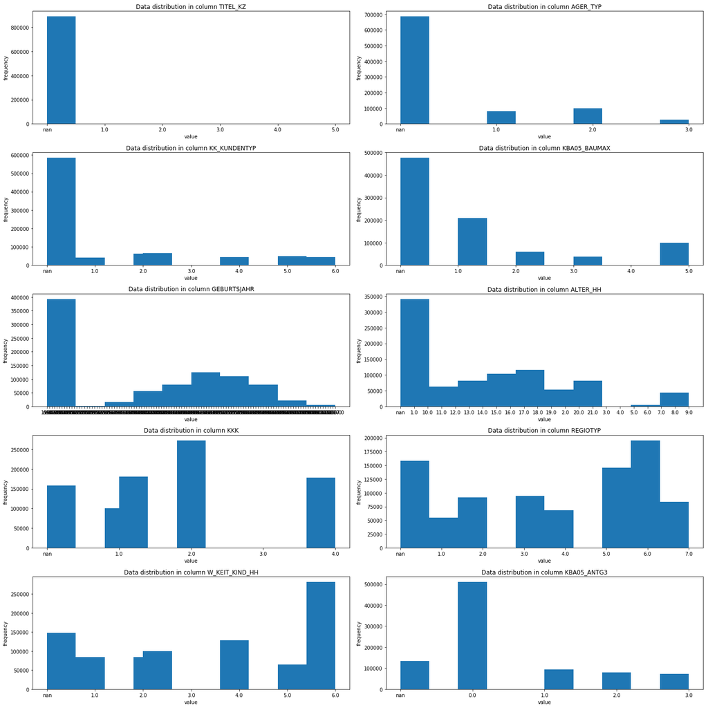

```python
# histograms for top 10:
fig = plt.figure(figsize=[20, 20])

for column, n in zip(top10.index, range(len(top10.index))):
    ax = fig.add_subplot(5,2,n+1)
    plt.hist(azdias[[column]])
    plt.xlabel("value")
    plt.ylabel("frequency")
    plt.title("Data distribution in column {}".format(column))

plt.tight_layout()
plt.show()
```

In the top 4 columns we have more than 50% of our data missing, so I decided to drop those columns for the further analysis.

```python
# Create a list of column names that have more than 50% of their data missing:
dropped = []
for column in top10.index:
    if top10['nan_percent'][column] > 50:
        dropped.append(column)
    else:
        continue

print(dropped)
```

```
['TITEL_KZ', 'AGER_TYP', 'KK_KUNDENTYP', 'KBA05_BAUMAX']
```

```python
# Remove the outlier columns from the dataset. (You'll perform other data
# engineering tasks such as re-encoding and imputation later.)
azdias = azdias.drop(dropped, axis=1)
```

```python
# Check new dataset shape:
azdias.shape
```

```
(891221, 81)
```

```python
# Remove dropped columns from feat_info:
feat_info = feat_info[~feat_info['attribute'].isin(dropped)]
```

```python
# Check new feat_info shape:
feat_info.shape
```

```
(81, 4)
```

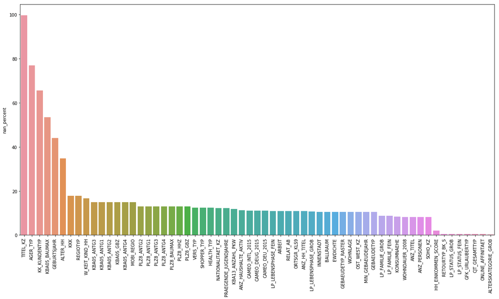

```python
# Check missing data percentages:

plt.figure(figsize=[20, 10])
plot = sns.barplot(x=azdias_nans.index, y=azdias_nans['nan_percent'], order=azdias_nans.index)
plot.set_xticklabels(plot.get_xticklabels(), rotation=90)

plt.show()
```

```python
# Without outliers:
azdias_nans_nooutliers = azdias_nans.drop(dropped, axis=0)
print(azdias_nans_nooutliers)
```

```
                       nan_count  nan_percent
GEBURTSJAHR               392318        44.02
ALTER_HH                  310267        34.81
KKK                       158064        17.74
REGIOTYP                  158064        17.74
W_KEIT_KIND_HH            147988        16.61
KBA05_ANTG3               133324        14.96
KBA05_ANTG1               133324        14.96
KBA05_ANTG2               133324        14.96
KBA05_GBZ                 133324        14.96
KBA05_ANTG4               133324        14.96
MOBI_REGIO                133324        14.96
PLZ8_ANTG2                116515        13.07
PLZ8_ANTG1                116515        13.07
PLZ8_ANTG3                116515        13.07
PLZ8_ANTG4                116515        13.07
PLZ8_BAUMAX               116515        13.07
PLZ8_HHZ                  116515        13.07
PLZ8_GBZ                  116515        13.07
VERS_TYP                  111196        12.48
SHOPPER_TYP               111196        12.48
HEALTH_TYP                111196        12.48
NATIONALITAET_KZ          108315        12.15
PRAEGENDE_JUGENDJAHRE     108164        12.14
KBA13_ANZAHL_PKW          105800        11.87
ANZ_HAUSHALTE_AKTIV        99611        11.18
CAMEO_INTL_2015            99352        11.15
CAMEO_DEUG_2015            99352        11.15
CAMEO_DEU_2015             99352        11.15
LP_LEBENSPHASE_FEIN        97632        10.95
ARBEIT                     97375        10.93
RELAT_AB                   97375        10.93
ORTSGR_KLS9                97274        10.91
ANZ_HH_TITEL               97008        10.88
LP_LEBENSPHASE_GROB        94572        10.61
INNENSTADT                 93740        10.52
BALLRAUM                   93740        10.52
EWDICHTE                   93740        10.52
GEBAEUDETYP_RASTER         93155        10.45
WOHNLAGE                   93148        10.45
OST_WEST_KZ                93148        10.45
MIN_GEBAEUDEJAHR           93148        10.45
GEBAEUDETYP                93148        10.45
LP_FAMILIE_GROB            77792         8.73
LP_FAMILIE_FEIN            77792         8.73
KONSUMNAEHE                73969         8.30
WOHNDAUER_2008             73499         8.25
ANZ_TITEL                  73499         8.25
ANZ_PERSONEN               73499         8.25
SOHO_KZ                    73499         8.25
HH_EINKOMMEN_SCORE         18348         2.06
RETOURTYP_BK_S              4854         0.54
LP_STATUS_GROB              4854         0.54
LP_STATUS_FEIN              4854         0.54
GFK_URLAUBERTYP             4854         0.54
CJT_GESAMTTYP               4854         0.54
ONLINE_AFFINITAET           4854         0.54
ALTERSKATEGORIE_GROB        2881         0.32
```

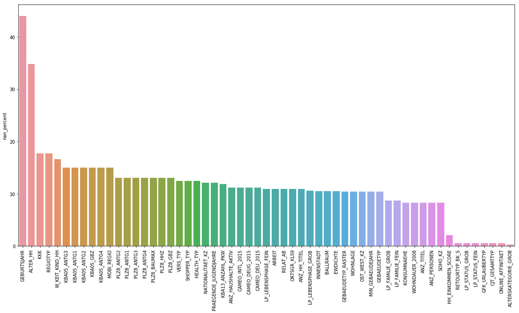

```python
plt.figure(figsize=[20,10])
plot = sns.barplot(x=azdias_nans_nooutliers.index, y=azdias_nans_nooutliers['nan_percent'], order=azdias_nans_nooutliers.index)
plot.set_xticklabels(plot.get_xticklabels(), rotation=90)
plt.show()
```

#### Discussion 1.1.2: Assess Missing Data in Each Column

We can see that in 4 columns ('TITEL_KZ', 'AGER_TYP', 'KK_KUNDENTYP', 'KBA05_BAUMAX') we have more than 50% of our data missing, which means these features won't be very useful for our further analysis. That is why I dropped these columns from the original 'azdias' dataset. We can also recognize some patterns considering the missing values. Several clusters can be made where the percentage of the missing data is the same, for example column names beggining with 'KBA05' have 14.96% missing values, 'PLZ8' have 13.07%, and so on.. These clusters can be seen on the barplots.

#### Step 1.1.3: Assess Missing Data in Each Row

Now, you'll perform a similar assessment for the rows of the dataset. How much data is missing in each row? As with the columns, you should see some groups of points that have a very different numbers of missing values. Divide the data into two subsets: one for data points that are above some threshold for missing values, and a second subset for points below that threshold.

In order to know what to do with the outlier rows, we should see if the distribution of data values on columns that are not missing data (or are missing very little data) are similar or different between the two groups. Select at least five of these columns and compare the distribution of values.

- You can use seaborn's [`countplot()`](https://seaborn.pydata.org/generated/seaborn.countplot.html) function to create a bar chart of code frequencies and matplotlib's [`subplot()`](https://matplotlib.org/api/_as_gen/matplotlib.pyplot.subplot.html) function to put bar charts for the two subplots side by side.
- To reduce repeated code, you might want to write a function that can perform this comparison, taking as one of its arguments a column to be compared.

Depending on what you observe in your comparison, this will have implications on how you approach your conclusions later in the analysis. If the distributions of non-missing features look similar between the data with many missing values and the data with few or no missing values, then we could argue that simply dropping those points from the analysis won't present a major issue. On the other hand, if the data with many missing values looks very different from the data with few or no missing values, then we should make a note on those data as special. We'll revisit these data later on. **Either way, you should continue your analysis for now using just the subset of the data with few or no missing values.**

```python
# How much data is missing in each row of the dataset?
missing_rows = azdias.isna().sum(axis=1)
print(missing_rows.head(20))
```

```
0     45
1      1
2      0
3      7
4      0
5      0
6      2
7      0
8      0
9      0
10     0
11    49
12     7
13     8
14    49
15     8
16     6
17    49
18     5
19     2
dtype: int64
```

```python
# Keep only the rows which have missing values
missing_rows = missing_rows[missing_rows != 0]
print(missing_rows.head(20))
```

```
0     45
1      1
3      7
6      2
11    49
12     7
13     8
14    49
15     8
16     6
17    49
18     5
19     2
20    12
21     2
22     2
23     9
24    49
25     5
26    21
dtype: int64
```

```python
missing_rows.sort_values(ascending=False, inplace=True)
```

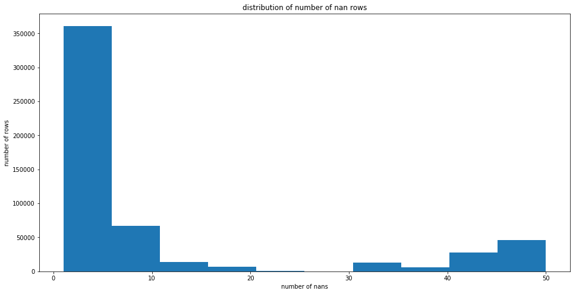

```python
plt.figure(figsize=[16,8])
plt.hist(missing_rows)
plt.xlabel("number of nans")
plt.ylabel("number of rows")
plt.title("distribution of number of nan rows")
plt.show()
```

```python
# Write code to divide the data into two subsets based on the number of missing
# values in each row.

# Define threshold based on the barplot:
nan_threshold = 30

# Divide the data into two subsets:
many_missing = missing_rows[missing_rows > nan_threshold]
few_missing = missing_rows[missing_rows <= nan_threshold]
```

```python
print("Total number of rows with many missing data: {}".format(many_missing.shape[0]),
      "\nThis is {} percent of all rows".format(np.round(100 * many_missing.shape[0] / azdias.shape[0], 2)))
```

```
Total number of rows with many missing data: 93164
This is 10.45 percent of all rows
```

```python
# Compare the distribution of values for at least five columns where there are
# no or few missing values, between the two subsets.

# 5 columns with no missing values:
nonan_columns = list(azdias.isna().sum()[azdias.isna().sum() == 0][:5].index)

# 5 columns with few missing values
fewnan_columns = list(azdias_nans.iloc[-5:].index)
```

```python
print(nonan_columns)
print(fewnan_columns)
```

```
['ANREDE_KZ', 'FINANZ_MINIMALIST', 'FINANZ_SPARER', 'FINANZ_VORSORGER', 'FINANZ_ANLEGER']
['LP_STATUS_FEIN', 'GFK_URLAUBERTYP', 'CJT_GESAMTTYP', 'ONLINE_AFFINITAET', 'ALTERSKATEGORIE_GROB']
```

```python
# Define a function for comparison:

def compare(column):
    fig = plt.figure(figsize=[12,5])
    ax1 = fig.add_subplot(1, 2, 1)
    ax1.set_title("Many missing rows")
    sns.countplot(azdias.loc[many_missing.index, column])

    ax2 = fig.add_subplot(1, 2, 2)
    ax2.set_title("Few missing rows")
    sns.countplot(azdias.loc[few_missing.index, column])

    fig.suptitle(column)
    plt.show()
```

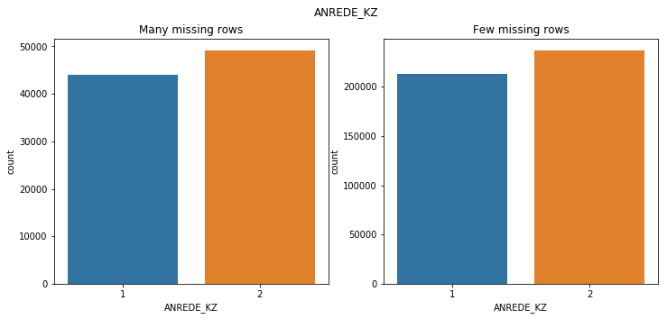

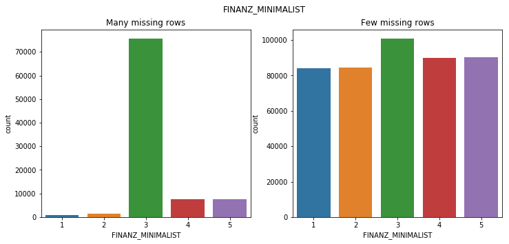

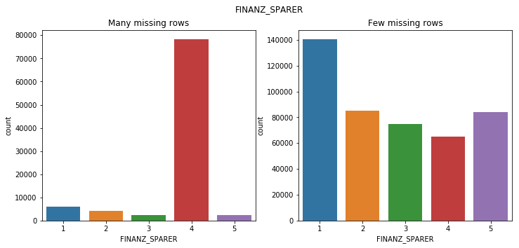

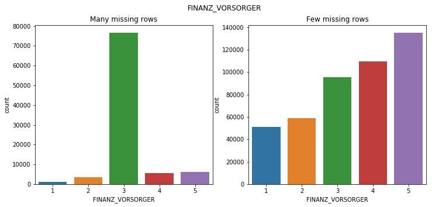

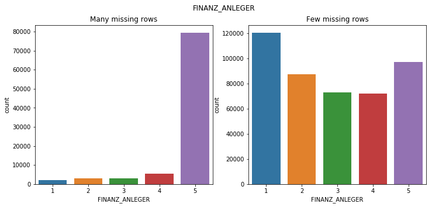

```python
# Do the comparison for 5 columns with 0 missing values
for column in nonan_columns:
    compare(column)
```

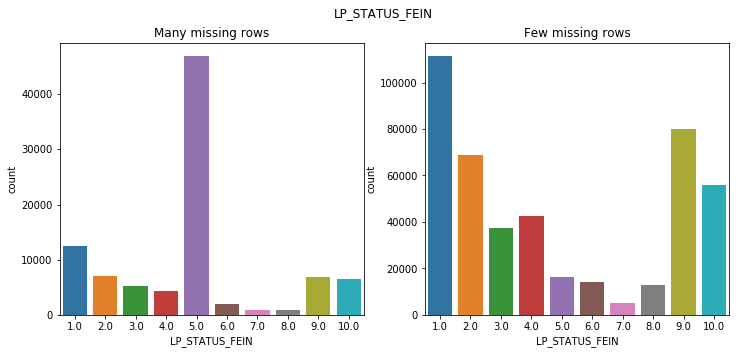

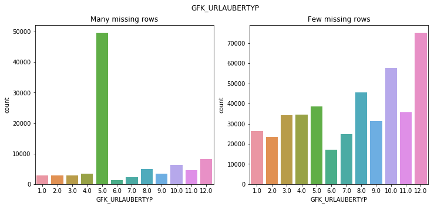

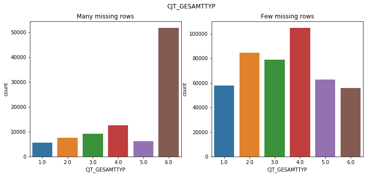

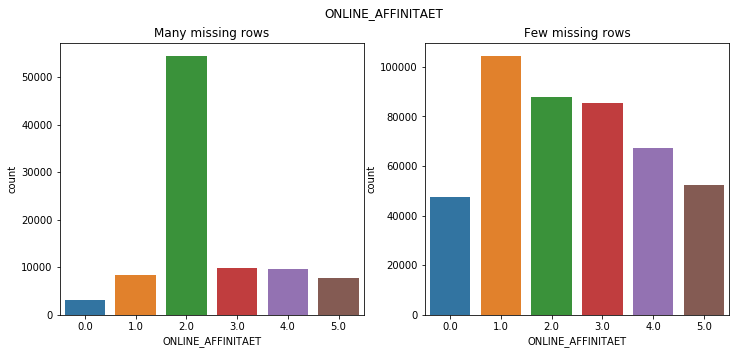

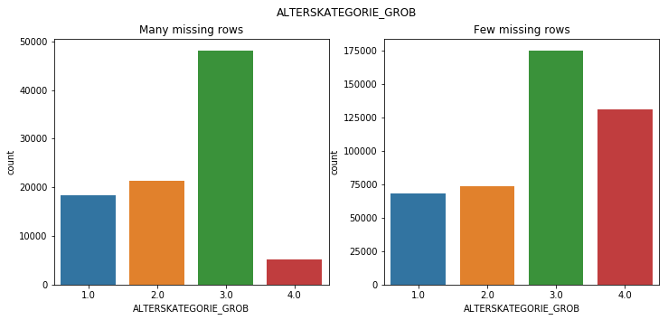

```python
# Do the comparison for 5 columns with few missing values:
for column in fewnan_columns:
    compare(column)
```

```python
# Make a subset of original dataset with many missing rows:
azdias_many_missing = azdias.iloc[many_missing.index]
```

#### Discussion 1.1.3: Assess Missing Data in Each Row

The analysis showed us that there are 93164 rows that are missing more than 30 values out of 81, and this is 10.45 percent of our whole dataset. The dataset was subsetted according to this threshold (30 rows), and it came out that in case of "ANDERE_KZ" = gender column, there is no significant effect on the data distribution. However we can see that the distribution of the data in the other picked columns with 0 or few missing values are qualitatively different if we do not consider the rows with many missing values.

### Step 1.2: Select and Re-Encode Features

Checking for missing data isn't the only way in which you can prepare a dataset for analysis. Since the unsupervised learning techniques to be used will only work on data that is encoded numerically, you need to make a few encoding changes or additional assumptions to be able to make progress. In addition, while almost all of the values in the dataset are encoded using numbers, not all of them represent numeric values. Check the third column of the feature summary (`feat_info`) for a summary of types of measurement.

- For numeric and interval data, these features can be kept without changes.
- Most of the variables in the dataset are ordinal in nature. While ordinal values may technically be non-linear in spacing, make the simplifying assumption that the ordinal variables can be treated as being interval in nature (that is, kept without any changes).
- Special handling may be necessary for the remaining two variable types: categorical, and 'mixed'.

In the first two parts of this sub-step, you will perform an investigation of the categorical and mixed-type features and make a decision on each of them, whether you will keep, drop, or re-encode each. Then, in the last part, you will create a new data frame with only the selected and engineered columns.

Data wrangling is often the trickiest part of the data analysis process, and there's a lot of it to be done here. But stick with it: once you're done with this step, you'll be ready to get to the machine learning parts of the project!

```python
# How many features are there of each data type?
feat_info.describe()
```

|  | attribute | information_level | type | missing_or_unknown |
| --- | --- | --- | --- | --- |
| count | 81 | 81 | 81 | 81 |
| unique | 81 | 9 | 5 | 9 |
| top | SEMIO_VERT | person | ordinal | [-1] |
| freq | 1 | 41 | 49 | 25 |

```python
types = feat_info['type'].value_counts()
print(types)
```

```
ordinal        49
categorical    18
numeric         7
mixed           6
interval        1
Name: type, dtype: int64
```

#### Step 1.2.1: Re-Encode Categorical Features

For categorical data, you would ordinarily need to encode the levels as dummy variables. Depending on the number of categories, perform one of the following:

- For binary (two-level) categoricals that take numeric values, you can keep them without needing to do anything.
- There is one binary variable that takes on non-numeric values. For this one, you need to re-encode the values as numbers or create a dummy variable.
- For multi-level categoricals (three or more values), you can choose to encode the values using multiple dummy variables (e.g. via [OneHotEncoder](http://scikit-learn.org/stable/modules/generated/sklearn.preprocessing.OneHotEncoder.html)), or (to keep things straightforward) just drop them from the analysis. As always, document your choices in the Discussion section.

```python
# Assess categorical variables: which are binary, which are multi-level, and
# which one needs to be re-encoded?
cat_vars = feat_info[feat_info['type'] == 'categorical']['attribute'].values
print(cat_vars)
```

```
['ANREDE_KZ' 'CJT_GESAMTTYP' 'FINANZTYP' 'GFK_URLAUBERTYP'
 'GREEN_AVANTGARDE' 'LP_FAMILIE_FEIN' 'LP_FAMILIE_GROB' 'LP_STATUS_FEIN'
 'LP_STATUS_GROB' 'NATIONALITAET_KZ' 'SHOPPER_TYP' 'SOHO_KZ' 'VERS_TYP'
 'ZABEOTYP' 'GEBAEUDETYP' 'OST_WEST_KZ' 'CAMEO_DEUG_2015' 'CAMEO_DEU_2015']
```

```python
# Create lists for binary and multi-level categorical variables:
binary_vars = []
multi_vars = []

for var in cat_vars:
    if azdias[var].nunique() == 2:
        binary_vars.append(var)
    else:
        multi_vars.append(var)

print(binary_vars)
print(multi_vars)
```

```
['ANREDE_KZ', 'GREEN_AVANTGARDE', 'SOHO_KZ', 'VERS_TYP', 'OST_WEST_KZ']
['CJT_GESAMTTYP', 'FINANZTYP', 'GFK_URLAUBERTYP', 'LP_FAMILIE_FEIN', 'LP_FAMILIE_GROB', 'LP_STATUS_FEIN', 'LP_STATUS_GROB', 'NATIONALITAET_KZ', 'SHOPPER_TYP', 'ZABEOTYP', 'GEBAEUDETYP', 'CAMEO_DEUG_2015', 'CAMEO_DEU_2015']
```

```python
# Check binary variables' values and data type:
for var in binary_vars:
    print("{} unique values are: {}".format(var, azdias[var].unique()), type(azdias[var].unique()[1]))
```

```
ANREDE_KZ unique values are: [1 2] <class 'numpy.int64'>
GREEN_AVANTGARDE unique values are: [0 1] <class 'numpy.int64'>
SOHO_KZ unique values are: [ nan   1.   0.] <class 'numpy.float64'>
VERS_TYP unique values are: [ nan   2.   1.] <class 'numpy.float64'>
OST_WEST_KZ unique values are: [nan 'W' 'O'] <class 'str'>
```

```python
for var in binary_vars:
    values = azdias[var].unique()[pd.isna(azdias[var].unique()) == False]
    azdias[var].replace(values, [0, 1], inplace=True)
    print(azdias[var].unique())
```

```
[0 1]
[0 1]
[ nan   0.   1.]
[ nan   0.   1.]
[ nan   0.   1.]
```

```python
# Check multi-level variables' values and data type:
for var in multi_vars:
    print("{} unique values are: {}".format(var, azdias[var].unique()), type(azdias[var].unique()[1]))
```

```
CJT_GESAMTTYP unique values are: [  2.   5.   3.   4.   1.   6.  nan] <class 'numpy.float64'>
FINANZTYP unique values are: [4 1 6 5 2 3] <class 'numpy.int64'>
GFK_URLAUBERTYP unique values are: [ 10.   1.   5.  12.   9.   3.   8.  11.   4.   2.   7.   6.  nan] <class 'numpy.float64'>
LP_FAMILIE_FEIN unique values are: [  2.   5.   1.  nan  10.   7.  11.   3.   8.   4.   6.   9.] <class 'numpy.float64'>
LP_FAMILIE_GROB unique values are: [  2.   3.   1.  nan   5.   4.] <class 'numpy.float64'>
LP_STATUS_FEIN unique values are: [  1.   2.   3.   9.   4.  10.   5.   8.   6.   7.  nan] <class 'numpy.float64'>
LP_STATUS_GROB unique values are: [  1.   2.   4.   5.   3.  nan] <class 'numpy.float64'>
NATIONALITAET_KZ unique values are: [ nan   1.   3.   2.] <class 'numpy.float64'>
SHOPPER_TYP unique values are: [ nan   3.   2.   1.   0.] <class 'numpy.float64'>
ZABEOTYP unique values are: [3 5 4 1 6 2] <class 'numpy.int64'>
GEBAEUDETYP unique values are: [ nan   8.   1.   3.   2.   6.   4.   5.] <class 'numpy.float64'>
CAMEO_DEUG_2015 unique values are: [nan '8' '4' '2' '6' '1' '9' '5' '7' '3'] <class 'str'>
CAMEO_DEU_2015 unique values are: [nan '8A' '4C' '2A' '6B' '8C' '4A' '2D' '1A' '1E' '9D' '5C' '8B' '7A' '5D'
 '9E' '9B' '1B' '3D' '4E' '4B' '3C' '5A' '7B' '9A' '6D' '6E' '2C' '7C' '9C'
 '7D' '5E' '1D' '8D' '6C' '6A' '5B' '4D' '3A' '2B' '7E' '3B' '6F' '5F' '1C'] <class 'str'>
```

```python
# Re-encode categorical variable(s) to be kept in the analysis.
azdias = pd.get_dummies(azdias, columns=multi_vars)
```

```python
print(azdias.shape)
```

```
(891221, 196)
```

#### Discussion 1.2.1: Re-Encode Categorical Features

After exploring the categorical variables I decided to keep all of them, since the re-encoding is relatively easy and computationally fast. I re-encoded the binary variables to 0 and 1 to be consistent, and I created dummy variables for the multi-level features.

#### Step 1.2.2: Engineer Mixed-Type Features

There are a handful of features that are marked as "mixed" in the feature summary that require special treatment in order to be included in the analysis. There are two in particular that deserve attention; the handling of the rest are up to your own choices:

- "PRAEGENDE_JUGENDJAHRE" combines information on three dimensions: generation by decade, movement (mainstream vs. avantgarde), and nation (east vs. west). While there aren't enough levels to disentangle east from west, you should create two new variables to capture the other two dimensions: an interval-type variable for decade, and a binary variable for movement.
- "CAMEO_INTL_2015" combines information on two axes: wealth and life stage. Break up the two-digit codes by their 'tens'-place and 'ones'-place digits into two new ordinal variables (which, for the purposes of this project, is equivalent to just treating them as their raw numeric values).
- If you decide to keep or engineer new features around the other mixed-type features, make sure you note your steps in the Discussion section.

Be sure to check `Data_Dictionary.md` for the details needed to finish these tasks.

```python
# Investigate "PRAEGENDE_JUGENDJAHRE" and engineer two new variables.
# Create dictionary for the decades:
decade_dict = {1 : 0, 2 : 0,
               3 : 1, 4 : 1,
               5 : 2, 6 : 2, 7 : 2,
               8 : 3, 9 : 3,
               10 : 4, 11 : 4, 12 : 4, 13 : 4,
               14 : 5, 15 : 5}

# Map and create decade column according to the dictionary:
azdias["PRAEGENDE_JUGENDJAHRE_decade"] = azdias["PRAEGENDE_JUGENDJAHRE"].map(decade_dict)

# Check results:
print(azdias["PRAEGENDE_JUGENDJAHRE_decade"].head(20))
```

```
0     NaN
1     5.0
2     5.0
3     3.0
4     3.0
5     1.0
6     4.0
7     3.0
8     4.0
9     5.0
10    1.0
11    NaN
12    3.0
13    5.0
14    NaN
15    2.0
16    5.0
17    NaN
18    4.0
19    3.0
Name: PRAEGENDE_JUGENDJAHRE_decade, dtype: float64
```

```python
# Create dictionary for movement:
movement_dict = {1 : 0, 3 : 0, 5 : 0, 8 : 0, 10 : 0, 12 : 0, 14 : 0,
                 2 : 1, 4 : 1, 6 : 1, 7 : 1, 9 : 1, 11 : 1, 13 : 1, 15 : 1}

# Map and create movement column according to the dictionary:
azdias["PRAEGENDE_JUGENDJAHRE_movement"] = azdias["PRAEGENDE_JUGENDJAHRE"].map(movement_dict)

#Check results:
print(azdias["PRAEGENDE_JUGENDJAHRE_movement"].head(20))
```

```
0     NaN
1     0.0
2     1.0
3     0.0
4     0.0
5     0.0
6     0.0
7     0.0
8     1.0
9     1.0
10    0.0
11    NaN
12    0.0
13    1.0
14    NaN
15    0.0
16    0.0
17    NaN
18    0.0
19    1.0
Name: PRAEGENDE_JUGENDJAHRE_movement, dtype: float64
```

```python
# Investigate "CAMEO_INTL_2015" and engineer two new variables.
print(type(azdias["CAMEO_INTL_2015"][20]))

# Create wealth column from the 1st character of str objects:
azdias["CAMEO_INTL_2015_wealth"] = azdias["CAMEO_INTL_2015"].apply(lambda x: int(str(x)[0]) if pd.isna(x) == False else np.nan)

# Check results
print(azdias["CAMEO_INTL_2015_wealth"].head())
print(azdias["CAMEO_INTL_2015"].head())
```

```
<class 'str'>
0    NaN
1    5.0
2    2.0
3    1.0
4    4.0
Name: CAMEO_INTL_2015_wealth, dtype: float64
0    NaN
1     51
2     24
3     12
4     43
Name: CAMEO_INTL_2015, dtype: object
```

```python
# Create life stage column from the 2nd character of str objects:
azdias["CAMEO_INTL_2015_lifestage"] = azdias["CAMEO_INTL_2015"].apply(lambda x: int(str(x)[1]) if pd.isna(x) == False else np.nan)

# Check results:
print(azdias["CAMEO_INTL_2015_lifestage"].head())
print(azdias["CAMEO_INTL_2015"].head())
```

```
0    NaN
1    1.0
2    4.0
3    2.0
4    3.0
Name: CAMEO_INTL_2015_lifestage, dtype: float64
0    NaN
1     51
2     24
3     12
4     43
Name: CAMEO_INTL_2015, dtype: object
```

```python
# Check shape of the dataset:
azdias.shape
```

```
(891221, 200)
```

```python
# Remove original columns from the dataset:
azdias = azdias.drop(["PRAEGENDE_JUGENDJAHRE", "CAMEO_INTL_2015"], axis=1)
```

```python
# Check shape after dropping columns:
azdias.shape
```

```
(891221, 198)
```

```python
mixed = feat_info[feat_info['type'] == "mixed"]
print(mixed)
```

```
                attribute information_level   type missing_or_unknown
15    LP_LEBENSPHASE_FEIN            person  mixed                [0]
16    LP_LEBENSPHASE_GROB            person  mixed                [0]
22  PRAEGENDE_JUGENDJAHRE            person  mixed             [-1,0]
56               WOHNLAGE          building  mixed               [-1]
59        CAMEO_INTL_2015     microcell_rr4  mixed            [-1,XX]
79            PLZ8_BAUMAX    macrocell_plz8  mixed             [-1,0]
```

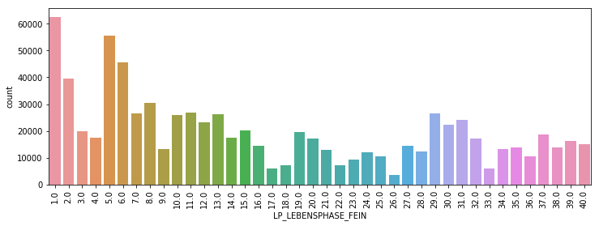

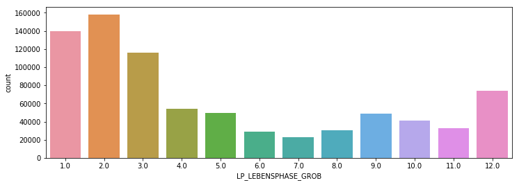

```python
# Check LP_LEBENSPHASE_FEIN and LP_LEBENSPHASE_GROB:
plt.figure(figsize=[12,4])
plot = sns.countplot(azdias["LP_LEBENSPHASE_FEIN"])
plot.set_xticklabels(plot.get_xticklabels(), rotation=90)
plt.show()

plt.figure(figsize=[12,4])
sns.countplot(azdias["LP_LEBENSPHASE_GROB"])
plt.show()
```

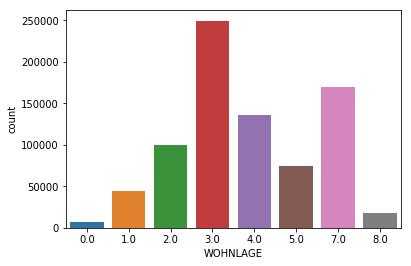

```python
# Check WOHNLAGE column:
sns.countplot(azdias["WOHNLAGE"])
plt.show()
```

```python
print(azdias["WOHNLAGE"].unique())
```

```
[ nan   4.   2.   7.   3.   5.   1.   8.   0.]
```

According to the information found in the Data_Dictionary.md the 0 values can be also considered as NaN values. 7 and 8 refers to rural neighborhood which can be another binary variable.

```python
# Re-encode 0 values:
azdias["WOHNLAGE"] = azdias["WOHNLAGE"].replace(0, np.nan)
```

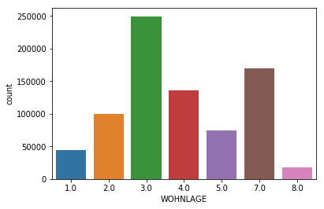

```python
# Check results:
sns.countplot(azdias["WOHNLAGE"])
plt.show()
```

```python
# Extract rural neighborhood as a binary variable in a new column:
# Dictionary for mapping:
rural_dict = {1 : 0, 2 : 0, 3 : 0, 4 : 0, 5 : 0,
              7 : 1, 8 : 1}

# Mapping:
azdias["WOHNLAGE_rural"] = azdias["WOHNLAGE"].map(rural_dict)
```

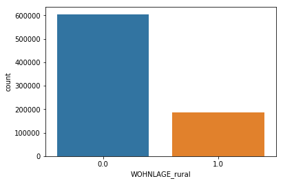

```python
# Check new column:
sns.countplot(azdias["WOHNLAGE_rural"])
plt.show()
```

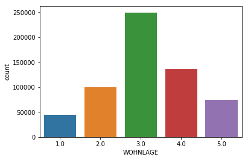

```python
# Finalize WOHNLAGE column by considering 7 and 8 values as NaNs:
azdias["WOHNLAGE"] = azdias["WOHNLAGE"].replace([7, 8], np.nan)

#Check final column (should be an ordinal scale from 1 to 5):
sns.countplot(azdias["WOHNLAGE"])
plt.show()
```

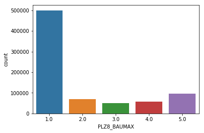

```python
# Check PLZ8_BAUMAX column:
sns.countplot(azdias["PLZ8_BAUMAX"])
plt.show()
```

We can extract the 5 values as a binary variable for business buildings (0,1)

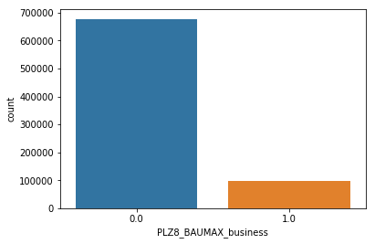

```python
# Create dictionary for mapping:
business_dict = {1 : 0, 2 : 0, 3 : 0, 4 : 0,
                 5 : 1}

# Create new column:
azdias["PLZ8_BAUMAX_business"] = azdias["PLZ8_BAUMAX"].map(business_dict)

# Check results:
sns.countplot(azdias["PLZ8_BAUMAX_business"])
plt.show()
```

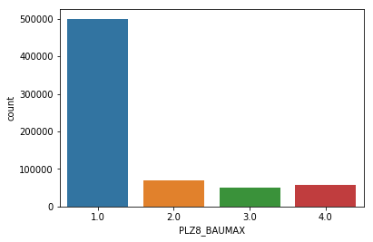

```python
# Finalize PLZ8_BAUMAX column by recoding 5 values with NaN:
azdias["PLZ8_BAUMAX"] = azdias["PLZ8_BAUMAX"].replace(5, np.nan)

# Check final column (should be an ordinal scale from 1 to 4):
sns.countplot(azdias["PLZ8_BAUMAX"])
plt.show()
```

#### Step 1.2.3: Complete Feature Selection

In order to finish this step up, you need to make sure that your data frame now only has the columns that you want to keep. To summarize, the dataframe should consist of the following:

- All numeric, interval, and ordinal type columns from the original dataset.
- Binary categorical features (all numerically-encoded).
- Engineered features from other multi-level categorical features and mixed features.

Make sure that for any new columns that you have engineered, that you've excluded the original columns from the final dataset. Otherwise, their values will interfere with the analysis later on the project. For example, you should not keep "PRAEGENDE_JUGENDJAHRE", since its values won't be useful for the algorithm: only the values derived from it in the engineered features you created should be retained. As a reminder, your data should only be from **the subset with few or no missing values**.

```python
azdias_many_missing.shape
```

```
(93164, 81)
```

```python
# If there are other re-engineering tasks you need to perform, make sure you
# take care of them here. (Dealing with missing data will come in step 2.1.)

# Remove rows with many missing column values:
azdias_few_missing = azdias.drop(azdias_many_missing.index, axis=0)

# Check shape (difference should be 93164):
print(azdias.shape)
print(azdias_few_missing.shape)
print("Difference: {}".format(azdias.shape[0] - azdias_few_missing.shape[0]))
```

```
(891221, 200)
(798057, 200)
Difference: 93164
```

```python
# Do whatever you need to in order to ensure that the dataframe only contains
# the columns that should be passed to the algorithm functions.

# Check columns:
for column in azdias.columns:
    values = azdias[column].unique()
    values.sort()
    print(column, values)
```

```
ALTERSKATEGORIE_GROB [  1.   2.   3.   4.  nan]
ANREDE_KZ [0 1]
FINANZ_MINIMALIST [1 2 3 4 5]
FINANZ_SPARER [1 2 3 4 5]
FINANZ_VORSORGER [1 2 3 4 5]
FINANZ_ANLEGER [1 2 3 4 5]
FINANZ_UNAUFFAELLIGER [1 2 3 4 5]
FINANZ_HAUSBAUER [1 2 3 4 5]
GEBURTSJAHR [ 1900.  1902.  1904.  1905.  1906.  1907.  1908.  1909.  1910.  1911.
  1912.  1913.  1914.  1915.  1916.  1917.  1918.  1919.  1920.  1921.
  1922.  1923.  1924.  1925.  1926.  1927.  1928.  1929.  1930.  1931.
  1932.  1933.  1934.  1935.  1936.  1937.  1938.  1939.  1940.  1941.
  1942.  1943.  1944.  1945.  1946.  1947.  1948.  1949.  1950.  1951.
  1952.  1953.  1954.  1955.  1956.  1957.  1958.  1959.  1960.  1961.
  1962.  1963.  1964.  1965.  1966.  1967.  1968.  1969.  1970.  1971.
  1972.  1973.  1974.  1975.  1976.  1977.  1978.  1979.  1980.  1981.
  1982.  1983.  1984.  1985.  1986.  1987.  1988.  1989.  1990.  1991.
  1992.  1993.  1994.  1995.  1996.  1997.  1998.  1999.  2000.  2001.
  2002.  2003.  2004.  2005.  2006.  2007.  2008.  2009.  2010.  2011.
  2012.  2013.  2014.  2015.  2016.  2017.    nan]
GREEN_AVANTGARDE [0 1]
HEALTH_TYP [  1.   2.   3.  nan]
LP_LEBENSPHASE_FEIN [  1.   2.   3.   4.   5.   6.   7.   8.   9.  10.  11.  12.  13.  14.  15.
  16.  17.  18.  19.  20.  21.  22.  23.  24.  25.  26.  27.  28.  29.  30.
  31.  32.  33.  34.  35.  36.  37.  38.  39.  40.  nan]
LP_LEBENSPHASE_GROB [  1.   2.   3.   4.   5.   6.   7.   8.   9.  10.  11.  12.  nan]
RETOURTYP_BK_S [  1.   2.   3.   4.   5.  nan]
SEMIO_SOZ [1 2 3 4 5 6 7]
SEMIO_FAM [1 2 3 4 5 6 7]
SEMIO_REL [1 2 3 4 5 6 7]
SEMIO_MAT [1 2 3 4 5 6 7]
SEMIO_VERT [1 2 3 4 5 6 7]
SEMIO_LUST [1 2 3 4 5 6 7]
SEMIO_ERL [1 2 3 4 5 6 7]
SEMIO_KULT [1 2 3 4 5 6 7]
SEMIO_RAT [1 2 3 4 5 6 7]
SEMIO_KRIT [1 2 3 4 5 6 7]
SEMIO_DOM [1 2 3 4 5 6 7]
SEMIO_KAEM [1 2 3 4 5 6 7]
SEMIO_PFLICHT [1 2 3 4 5 6 7]
```

[output cut: 190 more lines]

```
CAMEO_DEU_2015_8A [0 1]
CAMEO_DEU_2015_8B [0 1]
CAMEO_DEU_2015_8C [0 1]
CAMEO_DEU_2015_8D [0 1]
CAMEO_DEU_2015_9A [0 1]
CAMEO_DEU_2015_9B [0 1]
CAMEO_DEU_2015_9C [0 1]
CAMEO_DEU_2015_9D [0 1]
CAMEO_DEU_2015_9E [0 1]
PRAEGENDE_JUGENDJAHRE_decade [  0.   1.   2.   3.   4.   5.  nan]
PRAEGENDE_JUGENDJAHRE_movement [  0.   1.  nan]
CAMEO_INTL_2015_wealth [  1.   2.   3.   4.   5.  nan]
CAMEO_INTL_2015_lifestage [  1.   2.   3.   4.   5.  nan]
WOHNLAGE_rural [  0.   1.  nan]
PLZ8_BAUMAX_business [  0.   1.  nan]
```

### Step 1.3: Create a Cleaning Function

Even though you've finished cleaning up the general population demographics data, it's important to look ahead to the future and realize that you'll need to perform the same cleaning steps on the customer demographics data. In this substep, complete the function below to execute the main feature selection, encoding, and re-engineering steps you performed above. Then, when it comes to looking at the customer data in Step 3, you can just run this function on that DataFrame to get the trimmed dataset in a single step.

```python
def clean_data(df):
    """
    Perform feature trimming, re-encoding, and engineering for demographics
    data

    INPUT: Demographics DataFrame
    OUTPUT: Trimmed and cleaned demographics DataFrame
    """

    # Put in code here to execute all main cleaning steps:
    # convert missing value codes into NaNs, ...
    for attribute in df.columns:
        df[attribute] = df[attribute].replace(missing_df.loc[attribute][0], np.nan)


    # remove selected columns and rows, ...

    df = df.drop(dropped, axis=1)

    missing_rows = df.isna().sum(axis=1)
    many_missing = missing_rows[missing_rows > nan_threshold]

    df_many_missing = df.iloc[many_missing.index]

    df = df.drop(many_missing.index, axis=0)

    # select, re-encode, and engineer column values.
    for var in binary_vars:
        values = df[var].unique()[pd.isna(df[var].unique()) == False]
        df[var].replace(values, [0, 1], inplace=True)

    df = pd.get_dummies(df, columns=multi_vars)

    df["PRAEGENDE_JUGENDJAHRE_decade"] = df["PRAEGENDE_JUGENDJAHRE"].map(decade_dict)
    df["PRAEGENDE_JUGENDJAHRE_movement"] = df["PRAEGENDE_JUGENDJAHRE"].map(movement_dict)

    df["CAMEO_INTL_2015_wealth"] = df["CAMEO_INTL_2015"].apply(lambda x: int(str(x)[0]) if pd.isna(x) == False else np.nan)
    df["CAMEO_INTL_2015_lifestage"] = df["CAMEO_INTL_2015"].apply(lambda x: int(str(x)[1]) if pd.isna(x) == False else np.nan)

    df["WOHNLAGE"] = df["WOHNLAGE"].replace(0, np.nan)
    df["WOHNLAGE_rural"] = df["WOHNLAGE"].map(rural_dict)
    df["WOHNLAGE"] = df["WOHNLAGE"].replace([7, 8], np.nan)

    df["PLZ8_BAUMAX_business"] = df["PLZ8_BAUMAX"].map(business_dict)
    df["PLZ8_BAUMAX"] = df["PLZ8_BAUMAX"].replace(5, np.nan)

    df = df.drop(["PRAEGENDE_JUGENDJAHRE", "CAMEO_INTL_2015"], axis=1)

    # Return the cleaned dataframe.
    return df, df_many_missing
```

```python
# Check cleaning function:
azdias2 = pd.read_csv('Udacity_AZDIAS_Subset.csv', sep=';')
```

```python
azdias2_few_missing, azdias2_many_missing = clean_data(azdias2)
```

```python
print(azdias_few_missing.shape, azdias2_few_missing.shape)
print(azdias_many_missing.shape, azdias2_many_missing.shape)
```

```
(798057, 200) (798057, 200)
(93164, 81) (93164, 81)
```

## Step 2: Feature Transformation

### Step 2.1: Apply Feature Scaling

Before we apply dimensionality reduction techniques to the data, we need to perform feature scaling so that the principal component vectors are not influenced by the natural differences in scale for features. Starting from this part of the project, you'll want to keep an eye on the [API reference page for sklearn](http://scikit-learn.org/stable/modules/classes.html) to help you navigate to all of the classes and functions that you'll need. In this substep, you'll need to check the following:

- sklearn requires that data not have missing values in order for its estimators to work properly. So, before applying the scaler to your data, make sure that you've cleaned the DataFrame of the remaining missing values. This can be as simple as just removing all data points with missing data, or applying an [Imputer](http://scikit-learn.org/stable/modules/generated/sklearn.preprocessing.Imputer.html) to replace all missing values. You might also try a more complicated procedure where you temporarily remove missing values in order to compute the scaling parameters before re-introducing those missing values and applying imputation. Think about how much missing data you have and what possible effects each approach might have on your analysis, and justify your decision in the discussion section below.
- For the actual scaling function, a [StandardScaler](http://scikit-learn.org/stable/modules/generated/sklearn.preprocessing.StandardScaler.html) instance is suggested, scaling each feature to mean 0 and standard deviation 1.
- For these classes, you can make use of the `.fit_transform()` method to both fit a procedure to the data as well as apply the transformation to the data at the same time. Don't forget to keep the fit sklearn objects handy, since you'll be applying them to the customer demographics data towards the end of the project.

```python
# If you've not yet cleaned the dataset of all NaN values, then investigate and
# do that now.
features = azdias_few_missing.copy()

missing_pct = np.round(100 * features.isna().sum().sum() / (features.shape[0] * features.shape[1]), 2)
print("{} % of our data is missing".format(missing_pct))
```

```
1.09 % of our data is missing
```

```python
# Imputation of missing values with median
start = time.time()

imputer = Imputer(strategy="median")
imputed_features = imputer.fit_transform(features)

stop = time.time()

print("Imputation time: {:.3f} minutes".format((stop - start)/60))
```

```
Imputation time: 9.115 minutes
```

```python
# Apply feature scaling to the general population demographics data.
start = time.time()

scaler = StandardScaler()
scaled_features = scaler.fit_transform(imputed_features)

stop = time.time()

print("Scaling time: {:.3f} minutes".format((stop - start)/60))
```

```
Scaling time: 0.667 minutes
```

### Discussion 2.1: Apply Feature Scaling

I decided to replace NaN values with the median, since it is less sensitive for extreme values and outliers than the mean. I used sklearn's StandardScaler for feature scaling as suggested.

### Step 2.2: Perform Dimensionality Reduction

On your scaled data, you are now ready to apply dimensionality reduction techniques.

- Use sklearn's [PCA](http://scikit-learn.org/stable/modules/generated/sklearn.decomposition.PCA.html) class to apply principal component analysis on the data, thus finding the vectors of maximal variance in the data. To start, you should not set any parameters (so all components are computed) or set a number of components that is at least half the number of features (so there's enough features to see the general trend in variability).
- Check out the ratio of variance explained by each principal component as well as the cumulative variance explained. Try plotting the cumulative or sequential values using matplotlib's [`plot()`](https://matplotlib.org/api/_as_gen/matplotlib.pyplot.plot.html) function. Based on what you find, select a value for the number of transformed features you'll retain for the clustering part of the project.
- Once you've made a choice for the number of components to keep, make sure you re-fit a PCA instance to perform the decided-on transformation.

```python
scaled_features.shape
```

```
(798057, 200)
```

```python
# Set random_state:
random_state = 42
```

```python
# Apply PCA to the data.
start = time.time()

pca = PCA(int(scaled_features.shape[1] / 2), random_state=random_state)
features_pca = pca.fit_transform(scaled_features)

stop = time.time()

print("PCA application time: {:.3f} minutes".format((stop - start)/60))
```

```
PCA application time: 2.963 minutes
```

```python
# Investigate the variance accounted for by each principal component.

# Define scree plot (Here I use the code from helper_functions.py):
def scree_plot(pca):
    '''
    Creates a scree plot associated with the principal components

    INPUT: pca - the result of instantian of PCA in scikit learn

    OUTPUT:
            None
    '''
    num_components=len(pca.explained_variance_ratio_)
    ind = np.arange(num_components)
    vals = pca.explained_variance_ratio_

    plt.figure(figsize=(20, 10))
    ax = plt.subplot(111)
    cumvals = np.cumsum(vals)
    ax.bar(ind, vals)
    ax.plot(ind, cumvals)
    for i in range(num_components):
        ax.annotate(r"%s%%" % ((str(vals[i]*100)[:4])), (ind[i]+0.2, vals[i]), va="bottom", ha="center", fontsize=14, rotation=90)

    ax.xaxis.set_tick_params(width=0)
    ax.yaxis.set_tick_params(width=2, length=12)

    ax.set_xlabel("Principal Component")
    ax.set_ylabel("Variance Explained (%)")
    plt.title('Explained Variance Per Principal Component')
```

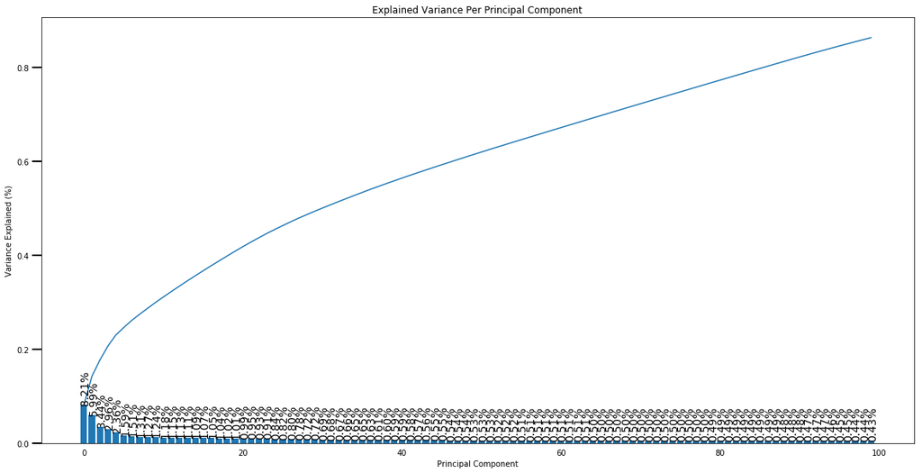

```python
scree_plot(pca)
```

```python
# Re-apply PCA to the data while selecting for number of components to retain.
start = time.time()

pca = PCA(50, random_state=random_state)
features_pca = pca.fit_transform(scaled_features)

stop = time.time()

print("PCA application time: {:.3f} minutes".format((stop - start)/60))
```

```
PCA application time: 2.704 minutes
```

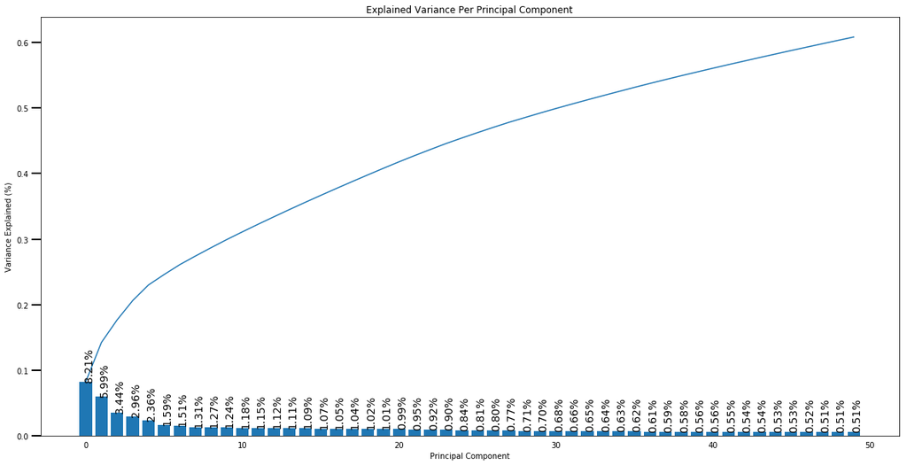

```python
scree_plot(pca)
```

### Discussion 2.2: Perform Dimensionality Reduction

For the first time I checked the number of features in the final dataset, and applied PCA for the half of that number. After checking the explained variance by the scree plot I decided to keep 50 components which after reapplying PCA explain around 60% of variance.

### Step 2.3: Interpret Principal Components

Now that we have our transformed principal components, it's a nice idea to check out the weight of each variable on the first few components to see if they can be interpreted in some fashion.

As a reminder, each principal component is a unit vector that points in the direction of highest variance (after accounting for the variance captured by earlier principal components). The further a weight is from zero, the more the principal component is in the direction of the corresponding feature. If two features have large weights of the same sign (both positive or both negative), then increases in one tend expect to be associated with increases in the other. To contrast, features with different signs can be expected to show a negative correlation: increases in one variable should result in a decrease in the other.

- To investigate the features, you should map each weight to their corresponding feature name, then sort the features according to weight. The most interesting features for each principal component, then, will be those at the beginning and end of the sorted list. Use the data dictionary document to help you understand these most prominent features, their relationships, and what a positive or negative value on the principal component might indicate.
- You should investigate and interpret feature associations from the first three principal components in this substep. To help facilitate this, you should write a function that you can call at any time to print the sorted list of feature weights, for the *i*-th principal component. This might come in handy in the next step of the project, when you interpret the tendencies of the discovered clusters.

```python
# Map weights for the first principal component to corresponding feature names
# and then print the linked values, sorted by weight.
# HINT: Try defining a function here or in a new cell that you can reuse in the
# other cells.

def get_feature_weights(data, pca, component):
    '''
    This function gets the weights for the component given by n_component argument
    and returns the top5 positive and top5 negative weights
    '''
    features = pd.DataFrame(pca.components_, columns=data.columns).iloc[component-1]
    features.sort_values(ascending=False, inplace=True)
    feature_weights = pd.concat([features.head(5), features.tail(5)])

    return feature_weights

def plot_weights(component, weights):
    '''
    This function plots the columns with top5 positive and top5 negative weights.
    '''
    plt.figure(figsize=[12, 4])
    plot = sns.barplot(x=feature_weights.index, y=feature_weights.values)
    plot.set_xticklabels(plot.get_xticklabels(), rotation=90)
    plt.xlabel("Features")
    plt.ylabel("Weights")
    plt.title("Component " + str(component))
    plt.show()

def print_sorted_weights(data, component):
    features = pd.DataFrame(pca.components_, columns=data.columns).iloc[component-1]
    features.sort_values(ascending=False, inplace=True)
    top5_pos_weights = features.head(5)
    top5_neg_weights = features.tail(5).sort_values()

    print("The top5 features with positive weights for component {}:\n\n{}".format(component, top5_pos_weights),
          "\n\nThe top5 features with negative weights for component {}:\n\n{}".format(component, top5_neg_weights))
```

```python
# Select the number of top components we want to check
n_components = 3
```

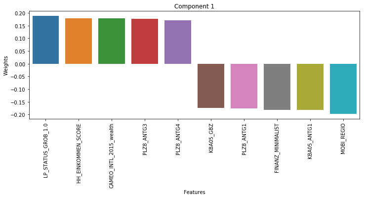

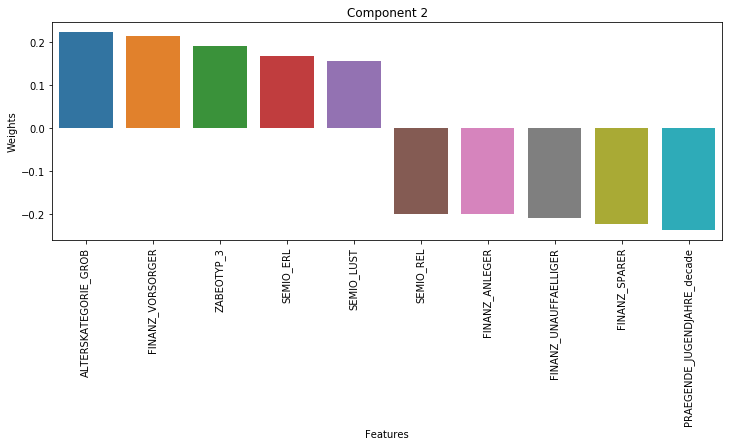

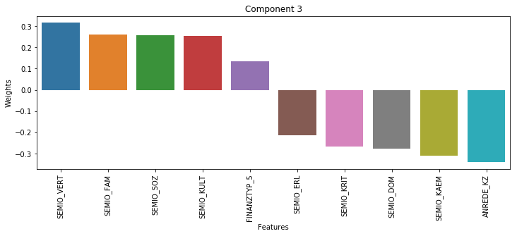

```python
# Analize weights for top X components:
for component in range(n_components):
    feature_weights = get_feature_weights(azdias_few_missing, pca, component+1)
    plot_weights(component + 1, feature_weights)
```

```python
# Map weights for the first principal component to corresponding feature names
# and then print the linked values, sorted by weight.
print_sorted_weights(azdias_few_missing, 1)
```

```
The top5 features with positive weights for component 1:

LP_STATUS_GROB_1.0        0.188013
HH_EINKOMMEN_SCORE        0.178499
CAMEO_INTL_2015_wealth    0.177545
PLZ8_ANTG3                0.175935
PLZ8_ANTG4                0.170665
Name: 0, dtype: float64

The top5 features with negative weights for component 1:

MOBI_REGIO          -0.196902
KBA05_ANTG1         -0.180951
FINANZ_MINIMALIST   -0.180872
PLZ8_ANTG1          -0.176782
KBA05_GBZ           -0.173507
Name: 0, dtype: float64
```

```python
# Map weights for the second principal component to corresponding feature names
# and then print the linked values, sorted by weight.
print_sorted_weights(azdias_few_missing, 2)
```

```
The top5 features with positive weights for component 2:

ALTERSKATEGORIE_GROB    0.223677
FINANZ_VORSORGER        0.215526
ZABEOTYP_3              0.190442
SEMIO_ERL               0.167259
SEMIO_LUST              0.157163
Name: 1, dtype: float64

The top5 features with negative weights for component 2:

PRAEGENDE_JUGENDJAHRE_decade   -0.237929
FINANZ_SPARER                  -0.224689
FINANZ_UNAUFFAELLIGER          -0.209954
FINANZ_ANLEGER                 -0.201405
SEMIO_REL                      -0.201220
Name: 1, dtype: float64
```

```python
# Map weights for the third principal component to corresponding feature names
# and then print the linked values, sorted by weight.
print_sorted_weights(azdias_few_missing, 3)
```

```
The top5 features with positive weights for component 3:

SEMIO_VERT     0.314913
SEMIO_FAM      0.260720
SEMIO_SOZ      0.255977
SEMIO_KULT     0.253507
FINANZTYP_5    0.133426
Name: 2, dtype: float64

The top5 features with negative weights for component 3:

ANREDE_KZ    -0.340098
SEMIO_KAEM   -0.309323
SEMIO_DOM    -0.276294
SEMIO_KRIT   -0.266839
SEMIO_ERL    -0.212066
Name: 2, dtype: float64
```

### Discussion 2.3: Interpret Principal Components

1. Component: The first component is related to social status, income, size of houses and movement patterns.

Variables

- LP_STATUS_GROB_1.0 = low-income earners
- HH_EINKOMMEN_SCORE = Estimated household net income (lower the value higher the income)
- CAMEO_INTL_2015_wealth = Wealth typology of household (higher the value poorer the household)
- PLZ8_ANTG3 = Number of 6-10 family houses in the PLZ8 region
- PLZ8_ANTG4 = Number of 10+ family houses in the PLZ8 region

have positive correlation with the first principal component.

Variables

- KBA05_GBZ = Number of buildings in the microcell
- PLZ8_ANTG1 = Number of 1-2 family houses in the PLZ8 region
- FINANZ_MINIMALIST = Financial typology (higher the value the less minimalist the person is)
- KBA05_ANTG1 = Number of 1-2 family houses in the microcell
- MOBI_REGIO = Movement patterns (higher the value lower the movement)

have negative correlation with the first principal component.

1. Component: The second component is related to age, financial attitude and personality

Variables

- ALTERSKATEGORIE_GROB = Estimated age based on given name analysis
- FINANZ_VORSORGER = Financial typology (higher the value the less careful the person is)
- ZABEOTYP_3 = Energy consumption typology, fair supplied
- SEMIO_ERL = Event-oriented personality (higher the value lower the affinity is)
- SEMIO_LUST = Sensual-minded personality (higher the value lower the affinity is)

have positive correlation with the second principal component.

Variables

1. Component: The third component is related to personality, financial type and gender

Variables

- SEMIO_VERT = dreamful personality (higher the value lower the affinity is)
- SEMIO_FAM = family-minded (higher the value lower the affinity is)
- SEMIO_SOZ = socially-minded (higher the value lower the affinity is)
- SEMIO_KULT = cultural-minded (higher the value lower the affinity is)
- FINANZTYP_5 = financial type - investor

have positive correlation with the third principal component.

Variables

## Step 3: Clustering

### Step 3.1: Apply Clustering to General Population

You've assessed and cleaned the demographics data, then scaled and transformed them. Now, it's time to see how the data clusters in the principal components space. In this substep, you will apply k-means clustering to the dataset and use the average within-cluster distances from each point to their assigned cluster's centroid to decide on a number of clusters to keep.

- Use sklearn's KMeans class to perform k-means clustering on the PCA-transformed data.
- Then, compute the average difference from each point to its assigned cluster's center. **Hint**: The KMeans object's `.score()` method might be useful here, but note that in sklearn, scores tend to be defined so that larger is better. Try applying it to a small, toy dataset, or use an internet search to help your understanding.
- Perform the above two steps for a number of different cluster counts. You can then see how the average distance decreases with an increasing number of clusters. However, each additional cluster provides a smaller net benefit. Use this fact to select a final number of clusters in which to group the data. **Warning**: because of the large size of the dataset, it can take a long time for the algorithm to resolve. The more clusters to fit, the longer the algorithm will take. You should test for cluster counts through at least 10 clusters to get the full picture, but you shouldn't need to test for a number of clusters above about 30.
- Once you've selected a final number of clusters to use, re-fit a KMeans instance to perform the clustering operation. Make sure that you also obtain the cluster assignments for the general demographics data, since you'll be using them in the final Step 3.3.

```python
# Define features sample size:
sample_size = int(np.round(len(features_pca)*0.25, 0))

# Create sample of pca_features:
sample_pca = features_pca[np.random.choice(features_pca.shape[0], sample_size, replace=False)]
```

```python
# Define function for running KMeans (Here I used the function that can be found in Lesson 1, 11. Screencast):

def run_kmeans(data, center):
    '''
    This function returns the kmeans score related to SSE for points to centers.
    '''
    # Define kmeans:
    kmeans = KMeans(n_clusters=center, random_state=random_state)

    # Fit model to the data:
    model = kmeans.fit(data)

    # Get score related to model fit:
    score = np.abs(model.score(data))

    return score
```

```
Run time: 27.637 minutes
```

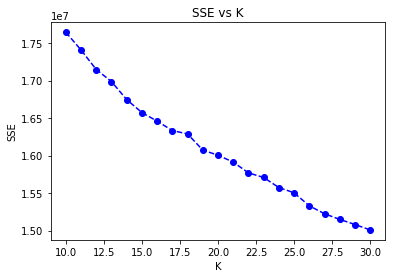

```python
# Over a number of different cluster counts...
# run k-means clustering on the data and...
# compute the average within-cluster distances.
# Investigate the change in within-cluster distance across number of clusters.
# HINT: Use matplotlib's plot function to visualize this relationship.

# I used the same logic and plotting as in Lesson 1, 11. Screencast

start = time.time()

centers = np.arange(10, 31)
scores = []

for center in centers:
    scores.append(run_kmeans(sample_pca, center))

plt.plot(centers, scores, linestyle='--', marker='o', color='b')
plt.xlabel('K')
plt.ylabel('SSE')
plt.title('SSE vs K')

stop = time.time()

print('Run time: {:.3f} minutes'.format((stop-start)/60))
```

An unambiguous "elbow" cannot be identified, but 25 seems to be a good value for K.

```python
# Re-fit the k-means model with the selected number of clusters and obtain
# cluster predictions for the general population demographics data.

start = time.time()

kmeans = KMeans(n_clusters=25, random_state=random_state)
labels = kmeans.fit_predict(features_pca)

stop = time.time()

print("Run time: {:.3f} minutes".format((stop-start)/60))
```

```
Run time: 7.218 minutes
```

### Discussion 3.1: Apply Clustering to General Population

I created a random sample from the 25% of the full dataset and ran the kmeans algorithm on it with 10 to 30 centers as proposed. I checked the connection between SSE and the number of centers on a plot, but no such "elbow" could be seen, so I decided to make 25 clusters in the end.

### Step 3.2: Apply All Steps to the Customer Data

Now that you have clusters and cluster centers for the general population, it's time to see how the customer data maps on to those clusters. Take care to not confuse this for re-fitting all of the models to the customer data. Instead, you're going to use the fits from the general population to clean, transform, and cluster the customer data. In the last step of the project, you will interpret how the general population fits apply to the customer data.

- Don't forget when loading in the customers data, that it is semicolon (`;`) delimited.
- Apply the same feature wrangling, selection, and engineering steps to the customer demographics using the `clean_data()` function you created earlier. (You can assume that the customer demographics data has similar meaning behind missing data patterns as the general demographics data.)
- Use the sklearn objects from the general demographics data, and apply their transformations to the customers data. That is, you should not be using a `.fit()` or `.fit_transform()` method to re-fit the old objects, nor should you be creating new sklearn objects! Carry the data through the feature scaling, PCA, and clustering steps, obtaining cluster assignments for all of the data in the customer demographics data.

```python
# Load in the customer demographics data.
customers = pd.read_csv("Udacity_CUSTOMERS_Subset.csv", sep=";")
```

```python
# Apply preprocessing, feature transformation, and clustering from the general
# demographics onto the customer data, obtaining cluster predictions for the
# customer demographics data.
customers_few_missing, customers_many_missing = clean_data(customers)
```

```python
# Check preprocessing results:
print(customers_few_missing.shape)
print(azdias_few_missing.shape)
```

```
(141725, 199)
(798057, 200)
```

It seems that 1 column is missing from the customers dataset. We need to check which one it is.

```python
# Get the missing column:
for column in azdias_few_missing.columns.values:
    if column in customers_few_missing.columns.values:
        continue
    else:
        print(column)
```

```
GEBAEUDETYP_5.0
```

The customers dataset has no value 5.0 in the column "GEBAEUDETYP". We need to add 1 row with that value, then redo the cleaning, and remove that row.

```python
# Check number of rows:
customers.shape
```

```
(191652, 85)
```

```python
# Make a copy:
customers_copy = customers.copy()
print(customers_copy.shape)
```

```
(191652, 85)
```

```python
# Copy and add the last row:
customers_copy = customers_copy.append(pd.DataFrame(data=customers_copy.tail(1).values, index=[customers_copy.index[-1]+1], columns=customers_copy.columns))
customers_copy.tail()
```

|  | AGER_TYP | ALTERSKATEGORIE_GROB | ANREDE_KZ | CJT_GESAMTTYP | FINANZ_MINIMALIST | FINANZ_SPARER | FINANZ_VORSORGER | FINANZ_ANLEGER | FINANZ_UNAUFFAELLIGER | FINANZ_HAUSBAUER | ... | PLZ8_ANTG1 | PLZ8_ANTG2 | PLZ8_ANTG3 | PLZ8_ANTG4 | PLZ8_BAUMAX | PLZ8_HHZ | PLZ8_GBZ | ARBEIT | ORTSGR_KLS9 | RELAT_AB |
| --- | --- | --- | --- | --- | --- | --- | --- | --- | --- | --- | --- | --- | --- | --- | --- | --- | --- | --- | --- | --- | --- |
| 191648 | NaN | 4 | 2 | 2 | 5 | 1 | 5 | 2 | 2 | 3 | ... | NaN | NaN | NaN | NaN | NaN | NaN | NaN | 1 | 4 | 1 |
| 191649 | 2 | 4 | 1 | 2 | 5 | 1 | 5 | 1 | 1 | 2 | ... | 3 | 2 | 2 | 1 | 1 | 5 | 5 | 3 | 7 | 5 |
| 191650 | 3 | 3 | 2 | 4 | 2 | 1 | 5 | 1 | 2 | 5 | ... | 3 | 2 | 1 | 1 | 1 | 2 | 3 | 3 | 4 | 4 |
| 191651 | 3 | 2 | 1 | 2 | 5 | 1 | 5 | 1 | 1 | 2 | ... | 3 | 2 | 0 | 0 | 1 | 4 | 5 | 1 | 3 | 1 |
| 191652 | 3 | 2 | 1 | 2 | 5 | 1 | 5 | 1 | 1 | 2 | ... | 3 | 2 | 0 | 0 | 1 | 4 | 5 | 1 | 3 | 1 |

5 rows × 85 columns

```python
# Replace last value in "GEBAEUDETYP" column with 5.0:
customers_copy.loc[customers_copy.index[-1], "GEBAEUDETYP"] = 5.0
customers_copy["GEBAEUDETYP"].tail()
```

```
191648    4
191649    1
191650    3
191651    1
191652    5
Name: GEBAEUDETYP, dtype: object
```

```python
# Redo data cleaning on customers_copy:
customers_few_missing, customers_many_missing = clean_data(customers_copy)
customers_few_missing.shape
```

```
(141726, 200)
```

```python
# Drop the added row:
customers_few_missing.drop([customers_copy.index[-1]], inplace=True)
```

```python
# Check results:
customers_few_missing.tail()
```

|  | ALTERSKATEGORIE_GROB | ANREDE_KZ | FINANZ_MINIMALIST | FINANZ_SPARER | FINANZ_VORSORGER | FINANZ_ANLEGER | FINANZ_UNAUFFAELLIGER | FINANZ_HAUSBAUER | GEBURTSJAHR | GREEN_AVANTGARDE | ... | CAMEO_DEU_2015_9B | CAMEO_DEU_2015_9C | CAMEO_DEU_2015_9D | CAMEO_DEU_2015_9E | PRAEGENDE_JUGENDJAHRE_decade | PRAEGENDE_JUGENDJAHRE_movement | CAMEO_INTL_2015_wealth | CAMEO_INTL_2015_lifestage | WOHNLAGE_rural | PLZ8_BAUMAX_business |
| --- | --- | --- | --- | --- | --- | --- | --- | --- | --- | --- | --- | --- | --- | --- | --- | --- | --- | --- | --- | --- | --- |
| 191647 | 3.0 | 0 | 5 | 1 | 5 | 1 | 1 | 2 | NaN | 0 | ... | 0 | 0 | 0 | 0 | 1.0 | 1.0 | 1.0 | 4.0 | 0.0 | 0.0 |
| 191648 | 4.0 | 1 | 5 | 1 | 5 | 2 | 2 | 3 | NaN | 1 | ... | 0 | 0 | 0 | 0 | 2.0 | 0.0 | 3.0 | 2.0 | 0.0 | NaN |
| 191649 | 4.0 | 0 | 5 | 1 | 5 | 1 | 1 | 2 | 1944.0 | 0 | ... | 0 | 0 | 0 | 0 | 1.0 | 1.0 | 2.0 | 4.0 | 0.0 | 0.0 |
| 191650 | 3.0 | 1 | 2 | 1 | 5 | 1 | 2 | 5 | NaN | 1 | ... | 0 | 0 | 0 | 0 | 3.0 | 0.0 | 2.0 | 4.0 | 0.0 | 0.0 |
| 191651 | 2.0 | 0 | 5 | 1 | 5 | 1 | 1 | 2 | 1937.0 | 1 | ... | 0 | 0 | 0 | 0 | 1.0 | 0.0 | 3.0 | 3.0 | 1.0 | 0.0 |

5 rows × 200 columns

```python
# Do the transformations on the customers_clean dataset:

imputed_customers = imputer.transform(customers_few_missing)

scaled_customers = scaler.transform(imputed_customers)

customers_pca = pca.transform(scaled_customers)

customers_labels = kmeans.predict(customers_pca)
```

### Step 3.3: Compare Customer Data to Demographics Data

At this point, you have clustered data based on demographics of the general population of Germany, and seen how the customer data for a mail-order sales company maps onto those demographic clusters. In this final substep, you will compare the two cluster distributions to see where the strongest customer base for the company is.

Consider the proportion of persons in each cluster for the general population, and the proportions for the customers. If we think the company's customer base to be universal, then the cluster assignment proportions should be fairly similar between the two. If there are only particular segments of the population that are interested in the company's products, then we should see a mismatch from one to the other. If there is a higher proportion of persons in a cluster for the customer data compared to the general population (e.g. 5% of persons are assigned to a cluster for the general population, but 15% of the customer data is closest to that cluster's centroid) then that suggests the people in that cluster to be a target audience for the company. On the other hand, the proportion of the data in a cluster being larger in the general population than the customer data (e.g. only 2% of customers closest to a population centroid that captures 6% of the data) suggests that group of persons to be outside of the target demographics.

Take a look at the following points in this step:

- Compute the proportion of data points in each cluster for the general population and the customer data. Visualizations will be useful here: both for the individual dataset proportions, but also to visualize the ratios in cluster representation between groups. Seaborn's [`countplot()`](https://seaborn.pydata.org/generated/seaborn.countplot.html) or [`barplot()`](https://seaborn.pydata.org/generated/seaborn.barplot.html) function could be handy.
  - Recall the analysis you performed in step 1.1.3 of the project, where you separated out certain data points from the dataset if they had more than a specified threshold of missing values. If you found that this group was qualitatively different from the main bulk of the data, you should treat this as an additional data cluster in this analysis. Make sure that you account for the number of data points in this subset, for both the general population and customer datasets, when making your computations!
- Which cluster or clusters are overrepresented in the customer dataset compared to the general population? Select at least one such cluster and infer what kind of people might be represented by that cluster. Use the principal component interpretations from step 2.3 or look at additional components to help you make this inference. Alternatively, you can use the `.inverse_transform()` method of the PCA and StandardScaler objects to transform centroids back to the original data space and interpret the retrieved values directly.
- Perform a similar investigation for the underrepresented clusters. Which cluster or clusters are underrepresented in the customer dataset compared to the general population, and what kinds of people are typified by these clusters?

As the distirbution of the data with many missing values defined in step 1.1.3 was qualitatively different, I need to create an additional cluster for those data. That cluster will be the n+1 cluster.

```python
np.unique(labels).max()
```

```
24
```

```python
# Create and attach n+1 cluster for both demographics and customers data:
azdias_many_missing_labels = np.full(azdias_many_missing.shape[0], np.unique(labels).max() + 1)
all_labels = np.concatenate([labels, azdias_many_missing_labels])

customers_many_missing_labels = np.full(customers_many_missing.shape[0], np.unique(customers_labels).max() + 1)
all_customer_labels = np.concatenate([customers_labels, customers_many_missing_labels])
```

```python
# Compare the proportion of data in each cluster for the customer data to the
# proportion of data in each cluster for the general population.

# Get the proportions of the clusters in dempgraphics data:
demographics_dict = {"proportion" : pd.Series(all_labels).value_counts(normalize=True, sort=False),
                     "datasource" : "demographics data"}

demographics_proportions = pd.DataFrame(demographics_dict)

# Get the proportions of the clusters in the customer data:
customers_dict = {"proportion" : pd.Series(all_customer_labels).value_counts(normalize=True, sort=False),
                  "datasource" : "customers data"}

customers_proportions = pd.DataFrame(customers_dict)
# Merge the 2 datasets in 1 dataset

all_proportions = pd.concat([demographics_proportions, customers_proportions])

all_proportions
```

|  | proportion | datasource |
| --- | --- | --- |
| 0 | 0.028749 | demographics data |
| 1 | 0.035727 | demographics data |
| 2 | 0.025033 | demographics data |
| 3 | 0.007016 | demographics data |
| 4 | 0.039419 | demographics data |
| 5 | 0.044402 | demographics data |
| 6 | 0.030758 | demographics data |
| 7 | 0.047789 | demographics data |
| 8 | 0.037614 | demographics data |
| 9 | 0.052251 | demographics data |
| 10 | 0.037124 | demographics data |
| 11 | 0.025523 | demographics data |
| 12 | 0.030052 | demographics data |
| 13 | 0.045920 | demographics data |
| 14 | 0.046782 | demographics data |
| 15 | 0.039116 | demographics data |
| 16 | 0.028982 | demographics data |
| 17 | 0.003523 | demographics data |
| 18 | 0.026274 | demographics data |
| 19 | 0.045935 | demographics data |
| 20 | 0.032524 | demographics data |
| 21 | 0.074166 | demographics data |
| 22 | 0.031779 | demographics data |
| 23 | 0.038218 | demographics data |
| 24 | 0.040788 | demographics data |
| 25 | 0.104535 | demographics data |
| 0 | 0.035705 | customers data |
| 1 | 0.001790 | customers data |
| 2 | 0.005593 | customers data |
| 3 | 0.007467 | customers data |
| 4 | 0.004075 | customers data |
| 5 | 0.068744 | customers data |
| 6 | 0.021852 | customers data |
| 7 | 0.024826 | customers data |
| 8 | 0.005244 | customers data |
| 9 | 0.045562 | customers data |
| 10 | 0.032048 | customers data |
| 11 | 0.001513 | customers data |
| 12 | 0.077907 | customers data |
| 13 | 0.003235 | customers data |
| 14 | 0.095621 | customers data |
| 15 | 0.010973 | customers data |
| 16 | 0.006694 | customers data |
| 17 | 0.014005 | customers data |
| 18 | 0.037208 | customers data |
| 19 | 0.004226 | customers data |
| 20 | 0.025859 | customers data |
| 21 | 0.040981 | customers data |
| 22 | 0.002338 | customers data |
| 23 | 0.055277 | customers data |
| 24 | 0.110748 | customers data |
| 25 | 0.260509 | customers data |

```python
# Check if demographics_proportions are well calculated (sum must be 1.0):
demographics_proportions.proportion.sum()
```

```
1.0
```

```python
# Check if customers_proportions are well calculated (sum must be 1.0):
customers_proportions.proportion.sum()
```

```
1.0
```

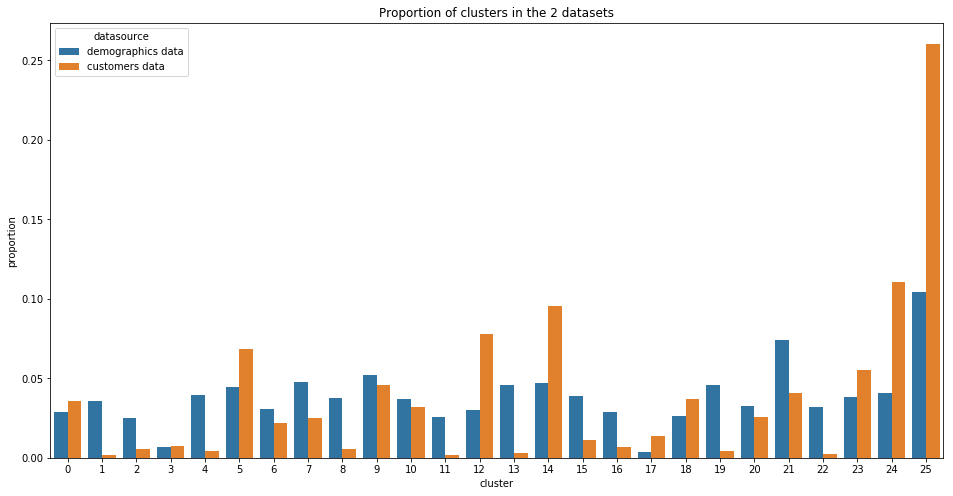

```python
# Visualize proportions:
plt.figure(figsize=[16, 8])
sns.barplot(x=all_proportions.index, y=all_proportions.proportion, hue=all_proportions.datasource)
plt.xlabel("cluster")
plt.title("Proportion of clusters in the 2 datasets")
plt.show()
```

```python
# Calculate proportion differences:
proportion_differences = customers_proportions.proportion - demographics_proportions.proportion
```